# Risk Factor Analysis

## Outcome Variable

**Outcome Variable:** wast_rec90d

## Predictor Variables

**Intervention Variable:** exclfeed3

**Adjustment Set:**

- arm
- sex
- brthmon
- W_mage
- meducyrs
- feducyrs
- hhwealth_quart
- hfoodsec
- W_mhtcm
- W_mwtkg
- W_mbmi
- vagbrth
- W_gagebrth
- W_birthwt
- W_birthlen
- W_nrooms
- W_nchldlt5
- month
- W_parity
- impfloor
- impsan
- safeh20
- delta_W_mage
- delta_meducyrs
- delta_feducyrs
- delta_hhwealth_quart
- delta_hfoodsec
- delta_W_mhtcm
- delta_W_mwtkg
- delta_W_mbmi
- delta_vagbrth
- delta_W_gagebrth
- delta_W_birthwt
- delta_W_birthlen
- delta_W_nrooms
- delta_W_nchldlt5
- delta_month
- delta_W_parity
- delta_impfloor
- delta_impsan
- delta_safeh20

## Stratifying Variables

The analysis was stratified on these variable(s):

- agecat
- studyid
- country

## Data Summary

| agecat | studyid | country | exclfeed3 | wast_rec90d | n_cell | n |
| --- | --- | --- | --- | --- | --- | --- |
| 0-24 months | ki0047075b-MAL-ED | BANGLADESH | 1 | 0 | 26 | 117 |
| 0-24 months | ki0047075b-MAL-ED | BANGLADESH | 1 | 1 | 51 | 117 |
| 0-24 months | ki0047075b-MAL-ED | BANGLADESH | 0 | 0 | 15 | 117 |
| 0-24 months | ki0047075b-MAL-ED | BANGLADESH | 0 | 1 | 25 | 117 |
| 0-24 months | ki0047075b-MAL-ED | BRAZIL | 1 | 0 | 4 | 22 |
| 0-24 months | ki0047075b-MAL-ED | BRAZIL | 1 | 1 | 5 | 22 |
| 0-24 months | ki0047075b-MAL-ED | BRAZIL | 0 | 0 | 2 | 22 |
| 0-24 months | ki0047075b-MAL-ED | BRAZIL | 0 | 1 | 11 | 22 |
| 0-24 months | ki0047075b-MAL-ED | INDIA | 1 | 0 | 27 | 162 |
| 0-24 months | ki0047075b-MAL-ED | INDIA | 1 | 1 | 51 | 162 |
| 0-24 months | ki0047075b-MAL-ED | INDIA | 0 | 0 | 35 | 162 |
| 0-24 months | ki0047075b-MAL-ED | INDIA | 0 | 1 | 49 | 162 |
| 0-24 months | ki0047075b-MAL-ED | NEPAL | 1 | 0 | 6 | 96 |
| 0-24 months | ki0047075b-MAL-ED | NEPAL | 1 | 1 | 16 | 96 |
| 0-24 months | ki0047075b-MAL-ED | NEPAL | 0 | 0 | 14 | 96 |
| 0-24 months | ki0047075b-MAL-ED | NEPAL | 0 | 1 | 60 | 96 |
| 0-24 months | ki0047075b-MAL-ED | PERU | 1 | 0 | 1 | 33 |
| 0-24 months | ki0047075b-MAL-ED | PERU | 1 | 1 | 3 | 33 |
| 0-24 months | ki0047075b-MAL-ED | PERU | 0 | 0 | 5 | 33 |
| 0-24 months | ki0047075b-MAL-ED | PERU | 0 | 1 | 24 | 33 |
| 0-24 months | ki0047075b-MAL-ED | SOUTH AFRICA | 1 | 0 | 0 | 77 |
| 0-24 months | ki0047075b-MAL-ED | SOUTH AFRICA | 1 | 1 | 2 | 77 |
| 0-24 months | ki0047075b-MAL-ED | SOUTH AFRICA | 0 | 0 | 12 | 77 |
| 0-24 months | ki0047075b-MAL-ED | SOUTH AFRICA | 0 | 1 | 63 | 77 |
| 0-24 months | ki0047075b-MAL-ED | TANZANIA, UNITED REPUBLIC OF | 1 | 0 | 1 | 44 |
| 0-24 months | ki0047075b-MAL-ED | TANZANIA, UNITED REPUBLIC OF | 1 | 1 | 7 | 44 |
| 0-24 months | ki0047075b-MAL-ED | TANZANIA, UNITED REPUBLIC OF | 0 | 0 | 7 | 44 |
| 0-24 months | ki0047075b-MAL-ED | TANZANIA, UNITED REPUBLIC OF | 0 | 1 | 29 | 44 |
| 0-24 months | ki1000108-CMC-V-BCS-2002 | INDIA | 1 | 0 | 5 | 11 |
| 0-24 months | ki1000108-CMC-V-BCS-2002 | INDIA | 1 | 1 | 6 | 11 |

[output cut: 162 more lines]

The following strata were considered:

- agecat: 0-24 months, studyid: ki0047075b-MAL-ED, country: BANGLADESH
- agecat: 0-24 months, studyid: ki0047075b-MAL-ED, country: BRAZIL
- agecat: 0-24 months, studyid: ki0047075b-MAL-ED, country: INDIA
- agecat: 0-24 months, studyid: ki0047075b-MAL-ED, country: NEPAL
- agecat: 0-24 months, studyid: ki0047075b-MAL-ED, country: PERU
- agecat: 0-24 months, studyid: ki0047075b-MAL-ED, country: SOUTH AFRICA
- agecat: 0-24 months, studyid: ki0047075b-MAL-ED, country: TANZANIA, UNITED REPUBLIC OF
- agecat: 0-24 months, studyid: ki1000108-CMC-V-BCS-2002, country: INDIA
- agecat: 0-24 months, studyid: ki1000108-IRC, country: INDIA
- agecat: 0-24 months, studyid: ki1000109-EE, country: PAKISTAN
- agecat: 0-24 months, studyid: ki1000304b-SAS-CompFeed, country: INDIA
- agecat: 0-24 months, studyid: ki1017093b-PROVIDE, country: BANGLADESH
- agecat: 0-24 months, studyid: ki1101329-Keneba, country: GAMBIA
- agecat: 0-24 months, studyid: ki1113344-GMS-Nepal, country: NEPAL
- agecat: 0-24 months, studyid: kiGH5241-JiVitA-3, country: BANGLADESH
- agecat: 0-24 months, studyid: kiGH5241-JiVitA-4, country: BANGLADESH
- agecat: 0-6 months, studyid: ki0047075b-MAL-ED, country: BANGLADESH
- agecat: 0-6 months, studyid: ki0047075b-MAL-ED, country: BRAZIL
- agecat: 0-6 months, studyid: ki0047075b-MAL-ED, country: INDIA
- agecat: 0-6 months, studyid: ki0047075b-MAL-ED, country: NEPAL
- agecat: 0-6 months, studyid: ki0047075b-MAL-ED, country: PERU
- agecat: 0-6 months, studyid: ki0047075b-MAL-ED, country: SOUTH AFRICA
- agecat: 0-6 months, studyid: ki0047075b-MAL-ED, country: TANZANIA, UNITED REPUBLIC OF
- agecat: 0-6 months, studyid: ki1000108-CMC-V-BCS-2002, country: INDIA
- agecat: 0-6 months, studyid: ki1000108-IRC, country: INDIA
- agecat: 0-6 months, studyid: ki1000109-EE, country: PAKISTAN
- agecat: 0-6 months, studyid: ki1000304b-SAS-CompFeed, country: INDIA
- agecat: 0-6 months, studyid: ki1017093b-PROVIDE, country: BANGLADESH
- agecat: 0-6 months, studyid: ki1101329-Keneba, country: GAMBIA
- agecat: 0-6 months, studyid: ki1113344-GMS-Nepal, country: NEPAL
- agecat: 0-6 months, studyid: kiGH5241-JiVitA-3, country: BANGLADESH
- agecat: 0-6 months, studyid: kiGH5241-JiVitA-4, country: BANGLADESH
- agecat: 6-24 months, studyid: ki0047075b-MAL-ED, country: BANGLADESH
- agecat: 6-24 months, studyid: ki0047075b-MAL-ED, country: BRAZIL
- agecat: 6-24 months, studyid: ki0047075b-MAL-ED, country: INDIA
- agecat: 6-24 months, studyid: ki0047075b-MAL-ED, country: NEPAL
- agecat: 6-24 months, studyid: ki0047075b-MAL-ED, country: PERU
- agecat: 6-24 months, studyid: ki0047075b-MAL-ED, country: SOUTH AFRICA
- agecat: 6-24 months, studyid: ki0047075b-MAL-ED, country: TANZANIA, UNITED REPUBLIC OF
- agecat: 6-24 months, studyid: ki1000108-CMC-V-BCS-2002, country: INDIA
- agecat: 6-24 months, studyid: ki1000108-IRC, country: INDIA
- agecat: 6-24 months, studyid: ki1000109-EE, country: PAKISTAN
- agecat: 6-24 months, studyid: ki1000304b-SAS-CompFeed, country: INDIA
- agecat: 6-24 months, studyid: ki1017093b-PROVIDE, country: BANGLADESH
- agecat: 6-24 months, studyid: ki1101329-Keneba, country: GAMBIA
- agecat: 6-24 months, studyid: ki1113344-GMS-Nepal, country: NEPAL
- agecat: 6-24 months, studyid: kiGH5241-JiVitA-3, country: BANGLADESH
- agecat: 6-24 months, studyid: kiGH5241-JiVitA-4, country: BANGLADESH

### Dropped Strata

Some strata were dropped due to rare outcomes:

- agecat: 0-24 months, studyid: ki0047075b-MAL-ED, country: BRAZIL
- agecat: 0-24 months, studyid: ki0047075b-MAL-ED, country: PERU
- agecat: 0-24 months, studyid: ki0047075b-MAL-ED, country: SOUTH AFRICA
- agecat: 0-24 months, studyid: ki0047075b-MAL-ED, country: TANZANIA, UNITED REPUBLIC OF
- agecat: 0-24 months, studyid: ki1000108-CMC-V-BCS-2002, country: INDIA
- agecat: 0-24 months, studyid: ki1000108-IRC, country: INDIA
- agecat: 0-24 months, studyid: ki1000109-EE, country: PAKISTAN
- agecat: 0-24 months, studyid: kiGH5241-JiVitA-4, country: BANGLADESH
- agecat: 0-6 months, studyid: ki0047075b-MAL-ED, country: BRAZIL
- agecat: 0-6 months, studyid: ki0047075b-MAL-ED, country: NEPAL
- agecat: 0-6 months, studyid: ki0047075b-MAL-ED, country: PERU
- agecat: 0-6 months, studyid: ki0047075b-MAL-ED, country: SOUTH AFRICA
- agecat: 0-6 months, studyid: ki0047075b-MAL-ED, country: TANZANIA, UNITED REPUBLIC OF
- agecat: 0-6 months, studyid: ki1000108-CMC-V-BCS-2002, country: INDIA
- agecat: 0-6 months, studyid: ki1000108-IRC, country: INDIA
- agecat: 0-6 months, studyid: ki1000109-EE, country: PAKISTAN
- agecat: 0-6 months, studyid: ki1000304b-SAS-CompFeed, country: INDIA
- agecat: 0-6 months, studyid: kiGH5241-JiVitA-4, country: BANGLADESH
- agecat: 6-24 months, studyid: ki0047075b-MAL-ED, country: BRAZIL
- agecat: 6-24 months, studyid: ki0047075b-MAL-ED, country: NEPAL
- agecat: 6-24 months, studyid: ki0047075b-MAL-ED, country: PERU
- agecat: 6-24 months, studyid: ki0047075b-MAL-ED, country: SOUTH AFRICA
- agecat: 6-24 months, studyid: ki0047075b-MAL-ED, country: TANZANIA, UNITED REPUBLIC OF
- agecat: 6-24 months, studyid: ki1000108-CMC-V-BCS-2002, country: INDIA
- agecat: 6-24 months, studyid: ki1000108-IRC, country: INDIA
- agecat: 6-24 months, studyid: ki1000109-EE, country: PAKISTAN
- agecat: 6-24 months, studyid: ki1000304b-SAS-CompFeed, country: INDIA
- agecat: 6-24 months, studyid: kiGH5241-JiVitA-3, country: BANGLADESH
- agecat: 6-24 months, studyid: kiGH5241-JiVitA-4, country: BANGLADESH

## Methods Detail

We’re interested in the causal parameters $E[Y_a]$ for all values of $a \in \mathcal{A}$. These parameters represent the mean outcome if, possibly contrary to fact, we intervened to set all units to have $A=a$. Under the randomization and positivity assumptions, these are identified by the statistical parameters $\psi_a=E_W[E_{Y|A,W}(Y|A=a,W)]$. In addition, we’re interested in the mean of $Y$, $E[Y]$ under no intervention (the observed mean). We will estimate these parameters by using SuperLearner to fit the relevant likelihood factors – $E_{Y|A,W}(Y|A=a,W)$ and $p(A=a|W)$, and then updating our likelihood fit using a joint TMLE.

For unadjusted analyses ($W=\{\}$), initial likelihoods were estimated using Lrnr_glm to estimate the simple $E(Y|A)$ and Lrnr_mean to estimate $p(A)$. For adjusted analyses, a small library containing Lrnr_glmnet, Lrnr_xgboost, and Lrnr_mean was used.

Having estimated these parameters, we will then use the delta method to estimate relative risks and attributable risks relative to a prespecified baseline level of $A$.

# Results Detail

## Results Plots

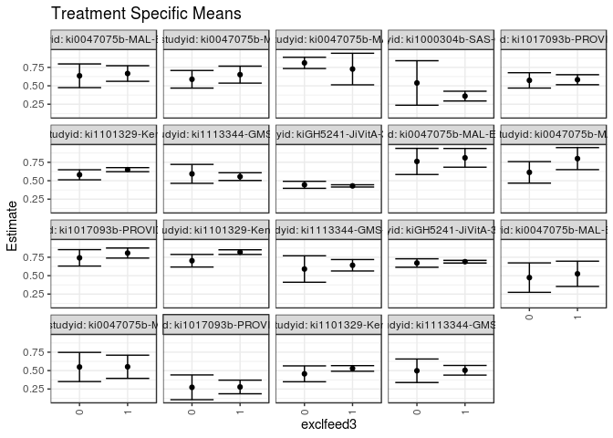

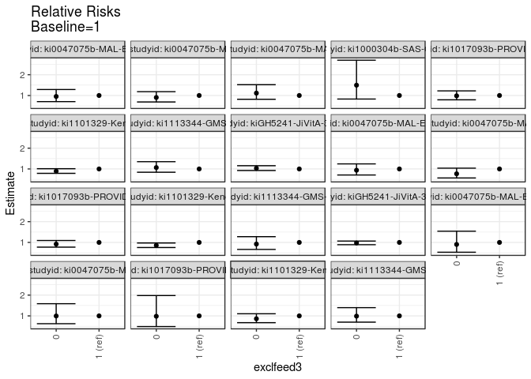

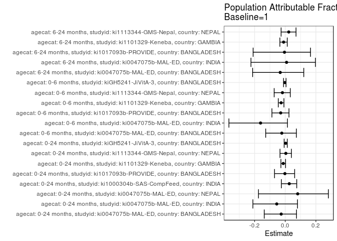

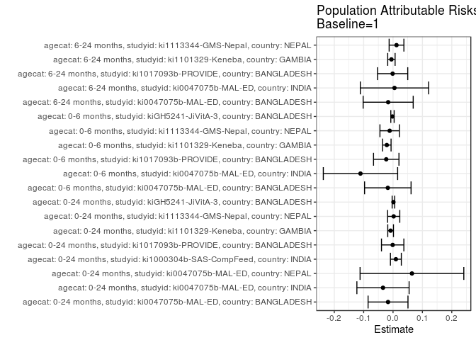

## Results Table

### Parameter: TSM

| agecat | studyid | country | intervention_level | baseline_level | estimate | ci_lower | ci_upper |
| --- | --- | --- | --- | --- | --- | --- | --- |
| 0-24 months | ki0047075b-MAL-ED | BANGLADESH | 1 | NA | 0.6665661 | 0.5605468 | 0.7725854 |
| 0-24 months | ki0047075b-MAL-ED | BANGLADESH | 0 | NA | 0.6357235 | 0.4749461 | 0.7965009 |
| 0-24 months | ki0047075b-MAL-ED | INDIA | 1 | NA | 0.6514344 | 0.5360163 | 0.7668526 |
| 0-24 months | ki0047075b-MAL-ED | INDIA | 0 | NA | 0.5883630 | 0.4687110 | 0.7080151 |
| 0-24 months | ki0047075b-MAL-ED | NEPAL | 1 | NA | 0.7272727 | 0.5132170 | 0.9413285 |
| 0-24 months | ki0047075b-MAL-ED | NEPAL | 0 | NA | 0.8108108 | 0.7343861 | 0.8872355 |
| 0-24 months | ki1000304b-SAS-CompFeed | INDIA | 1 | NA | 0.3600000 | 0.2937351 | 0.4262649 |
| 0-24 months | ki1000304b-SAS-CompFeed | INDIA | 0 | NA | 0.5384615 | 0.2364546 | 0.8404685 |
| 0-24 months | ki1017093b-PROVIDE | BANGLADESH | 1 | NA | 0.5823698 | 0.5142141 | 0.6505255 |
| 0-24 months | ki1017093b-PROVIDE | BANGLADESH | 0 | NA | 0.5734224 | 0.4693151 | 0.6775298 |
| 0-24 months | ki1101329-Keneba | GAMBIA | 1 | NA | 0.6500269 | 0.6225174 | 0.6775365 |
| 0-24 months | ki1101329-Keneba | GAMBIA | 0 | NA | 0.5806902 | 0.5123410 | 0.6490393 |
| 0-24 months | ki1113344-GMS-Nepal | NEPAL | 1 | NA | 0.5558160 | 0.5031403 | 0.6084918 |
| 0-24 months | ki1113344-GMS-Nepal | NEPAL | 0 | NA | 0.5930325 | 0.4645490 | 0.7215160 |
| 0-24 months | kiGH5241-JiVitA-3 | BANGLADESH | 1 | NA | 0.4294633 | 0.4142056 | 0.4447211 |
| 0-24 months | kiGH5241-JiVitA-3 | BANGLADESH | 0 | NA | 0.4443238 | 0.3966193 | 0.4920284 |
| 0-6 months | ki0047075b-MAL-ED | BANGLADESH | 1 | NA | 0.8108108 | 0.6837788 | 0.9378428 |
| 0-6 months | ki0047075b-MAL-ED | BANGLADESH | 0 | NA | 0.7619048 | 0.5846570 | 0.9391525 |
| 0-6 months | ki0047075b-MAL-ED | INDIA | 1 | NA | 0.8000000 | 0.6503909 | 0.9496091 |
| 0-6 months | ki0047075b-MAL-ED | INDIA | 0 | NA | 0.6136364 | 0.4674979 | 0.7597749 |
| 0-6 months | ki1017093b-PROVIDE | BANGLADESH | 1 | NA | 0.8068795 | 0.7386464 | 0.8751126 |
| 0-6 months | ki1017093b-PROVIDE | BANGLADESH | 0 | NA | 0.7418528 | 0.6301690 | 0.8535366 |
| 0-6 months | ki1101329-Keneba | GAMBIA | 1 | NA | 0.8196426 | 0.7881216 | 0.8511636 |
| 0-6 months | ki1101329-Keneba | GAMBIA | 0 | NA | 0.7024603 | 0.6170828 | 0.7878378 |
| 0-6 months | ki1113344-GMS-Nepal | NEPAL | 1 | NA | 0.6412986 | 0.5636574 | 0.7189397 |
| 0-6 months | ki1113344-GMS-Nepal | NEPAL | 0 | NA | 0.5903629 | 0.4106563 | 0.7700695 |
| 0-6 months | kiGH5241-JiVitA-3 | BANGLADESH | 1 | NA | 0.6893700 | 0.6711296 | 0.7076105 |
| 0-6 months | kiGH5241-JiVitA-3 | BANGLADESH | 0 | NA | 0.6716004 | 0.6141448 | 0.7290561 |
| 6-24 months | ki0047075b-MAL-ED | BANGLADESH | 1 | NA | 0.5250000 | 0.3534413 | 0.6965587 |
| 6-24 months | ki0047075b-MAL-ED | BANGLADESH | 0 | NA | 0.4736842 | 0.2738216 | 0.6735468 |
| 6-24 months | ki0047075b-MAL-ED | INDIA | 1 | NA | 0.5518257 | 0.3942050 | 0.7094465 |
| 6-24 months | ki0047075b-MAL-ED | INDIA | 0 | NA | 0.5491210 | 0.3508869 | 0.7473550 |
| 6-24 months | ki1017093b-PROVIDE | BANGLADESH | 1 | NA | 0.2777778 | 0.1853143 | 0.3702413 |
| 6-24 months | ki1017093b-PROVIDE | BANGLADESH | 0 | NA | 0.2727273 | 0.1045711 | 0.4408835 |
| 6-24 months | ki1101329-Keneba | GAMBIA | 1 | NA | 0.5294305 | 0.4915601 | 0.5673008 |
| 6-24 months | ki1101329-Keneba | GAMBIA | 0 | NA | 0.4560423 | 0.3482888 | 0.5637958 |
| 6-24 months | ki1113344-GMS-Nepal | NEPAL | 1 | NA | 0.5042390 | 0.4386362 | 0.5698417 |
| 6-24 months | ki1113344-GMS-Nepal | NEPAL | 0 | NA | 0.4978449 | 0.3381889 | 0.6575009 |

### Parameter: E(Y)

| agecat | studyid | country | intervention_level | baseline_level | estimate | ci_lower | ci_upper |
| --- | --- | --- | --- | --- | --- | --- | --- |
| 0-24 months | ki0047075b-MAL-ED | BANGLADESH | NA | NA | 0.6495726 | 0.5607849 | 0.7383604 |
| 0-24 months | ki0047075b-MAL-ED | INDIA | NA | NA | 0.6172840 | 0.5340594 | 0.7005085 |
| 0-24 months | ki0047075b-MAL-ED | NEPAL | NA | NA | 0.7916667 | 0.7146386 | 0.8686947 |
| 0-24 months | ki1000304b-SAS-CompFeed | INDIA | NA | NA | 0.3697479 | 0.3045176 | 0.4349782 |
| 0-24 months | ki1017093b-PROVIDE | BANGLADESH | NA | NA | 0.5811688 | 0.5245443 | 0.6377934 |
| 0-24 months | ki1101329-Keneba | GAMBIA | NA | NA | 0.6418109 | 0.6160920 | 0.6675299 |
| 0-24 months | ki1113344-GMS-Nepal | NEPAL | NA | NA | 0.5580448 | 0.5093588 | 0.6067308 |
| 0-24 months | kiGH5241-JiVitA-3 | BANGLADESH | NA | NA | 0.4308756 | 0.4161410 | 0.4456101 |
| 0-6 months | ki0047075b-MAL-ED | BANGLADESH | NA | NA | 0.7931034 | 0.6894917 | 0.8967152 |
| 0-6 months | ki0047075b-MAL-ED | INDIA | NA | NA | 0.6891892 | 0.5810852 | 0.7972932 |
| 0-6 months | ki1017093b-PROVIDE | BANGLADESH | NA | NA | 0.7837838 | 0.7252863 | 0.8422812 |
| 0-6 months | ki1101329-Keneba | GAMBIA | NA | NA | 0.7984496 | 0.7683939 | 0.8285053 |
| 0-6 months | ki1113344-GMS-Nepal | NEPAL | NA | NA | 0.6298343 | 0.5587812 | 0.7008873 |
| 0-6 months | kiGH5241-JiVitA-3 | BANGLADESH | NA | NA | 0.6875000 | 0.6700777 | 0.7049223 |
| 6-24 months | ki0047075b-MAL-ED | BANGLADESH | NA | NA | 0.5084746 | 0.3754416 | 0.6415076 |
| 6-24 months | ki0047075b-MAL-ED | INDIA | NA | NA | 0.5568182 | 0.4384773 | 0.6751591 |
| 6-24 months | ki1017093b-PROVIDE | BANGLADESH | NA | NA | 0.2764228 | 0.1950773 | 0.3577682 |
| 6-24 months | ki1101329-Keneba | GAMBIA | NA | NA | 0.5239207 | 0.4881434 | 0.5596979 |
| 6-24 months | ki1113344-GMS-Nepal | NEPAL | NA | NA | 0.5161290 | 0.4555456 | 0.5767125 |

### Parameter: RR

| agecat | studyid | country | intervention_level | baseline_level | estimate | ci_lower | ci_upper |
| --- | --- | --- | --- | --- | --- | --- | --- |
| 0-24 months | ki0047075b-MAL-ED | BANGLADESH | 1 | 1 | 1.0000000 | 1.0000000 | 1.0000000 |
| 0-24 months | ki0047075b-MAL-ED | BANGLADESH | 0 | 1 | 0.9537291 | 0.7061120 | 1.2881798 |
| 0-24 months | ki0047075b-MAL-ED | INDIA | 1 | 1 | 1.0000000 | 1.0000000 | 1.0000000 |
| 0-24 months | ki0047075b-MAL-ED | INDIA | 0 | 1 | 0.9031807 | 0.6889283 | 1.1840643 |
| 0-24 months | ki0047075b-MAL-ED | NEPAL | 1 | 1 | 1.0000000 | 1.0000000 | 1.0000000 |
| 0-24 months | ki0047075b-MAL-ED | NEPAL | 0 | 1 | 1.1148649 | 0.8180289 | 1.5194129 |
| 0-24 months | ki1000304b-SAS-CompFeed | INDIA | 1 | 1 | 1.0000000 | 1.0000000 | 1.0000000 |
| 0-24 months | ki1000304b-SAS-CompFeed | INDIA | 0 | 1 | 1.4957265 | 0.8288715 | 2.6990889 |
| 0-24 months | ki1017093b-PROVIDE | BANGLADESH | 1 | 1 | 1.0000000 | 1.0000000 | 1.0000000 |
| 0-24 months | ki1017093b-PROVIDE | BANGLADESH | 0 | 1 | 0.9846362 | 0.7928367 | 1.2228350 |
| 0-24 months | ki1101329-Keneba | GAMBIA | 1 | 1 | 1.0000000 | 1.0000000 | 1.0000000 |
| 0-24 months | ki1101329-Keneba | GAMBIA | 0 | 1 | 0.8933325 | 0.7887960 | 1.0117228 |
| 0-24 months | ki1113344-GMS-Nepal | NEPAL | 1 | 1 | 1.0000000 | 1.0000000 | 1.0000000 |
| 0-24 months | ki1113344-GMS-Nepal | NEPAL | 0 | 1 | 1.0669582 | 0.8427466 | 1.3508211 |
| 0-24 months | kiGH5241-JiVitA-3 | BANGLADESH | 1 | 1 | 1.0000000 | 1.0000000 | 1.0000000 |
| 0-24 months | kiGH5241-JiVitA-3 | BANGLADESH | 0 | 1 | 1.0346025 | 0.9256383 | 1.1563937 |
| 0-6 months | ki0047075b-MAL-ED | BANGLADESH | 1 | 1 | 1.0000000 | 1.0000000 | 1.0000000 |
| 0-6 months | ki0047075b-MAL-ED | BANGLADESH | 0 | 1 | 0.9396825 | 0.7098559 | 1.2439191 |
| 0-6 months | ki0047075b-MAL-ED | INDIA | 1 | 1 | 1.0000000 | 1.0000000 | 1.0000000 |
| 0-6 months | ki0047075b-MAL-ED | INDIA | 0 | 1 | 0.7670455 | 0.5666415 | 1.0383263 |
| 0-6 months | ki1017093b-PROVIDE | BANGLADESH | 1 | 1 | 1.0000000 | 1.0000000 | 1.0000000 |
| 0-6 months | ki1017093b-PROVIDE | BANGLADESH | 0 | 1 | 0.9194096 | 0.7732694 | 1.0931689 |
| 0-6 months | ki1101329-Keneba | GAMBIA | 1 | 1 | 1.0000000 | 1.0000000 | 1.0000000 |
| 0-6 months | ki1101329-Keneba | GAMBIA | 0 | 1 | 0.8570324 | 0.7549542 | 0.9729127 |
| 0-6 months | ki1113344-GMS-Nepal | NEPAL | 1 | 1 | 1.0000000 | 1.0000000 | 1.0000000 |
| 0-6 months | ki1113344-GMS-Nepal | NEPAL | 0 | 1 | 0.9205741 | 0.6635197 | 1.2772141 |
| 0-6 months | kiGH5241-JiVitA-3 | BANGLADESH | 1 | 1 | 1.0000000 | 1.0000000 | 1.0000000 |
| 0-6 months | kiGH5241-JiVitA-3 | BANGLADESH | 0 | 1 | 0.9742235 | 0.8909929 | 1.0652288 |
| 6-24 months | ki0047075b-MAL-ED | BANGLADESH | 1 | 1 | 1.0000000 | 1.0000000 | 1.0000000 |
| 6-24 months | ki0047075b-MAL-ED | BANGLADESH | 0 | 1 | 0.9022556 | 0.5291159 | 1.5385386 |
| 6-24 months | ki0047075b-MAL-ED | INDIA | 1 | 1 | 1.0000000 | 1.0000000 | 1.0000000 |
| 6-24 months | ki0047075b-MAL-ED | INDIA | 0 | 1 | 0.9950985 | 0.6240984 | 1.5866423 |
| 6-24 months | ki1017093b-PROVIDE | BANGLADESH | 1 | 1 | 1.0000000 | 1.0000000 | 1.0000000 |
| 6-24 months | ki1017093b-PROVIDE | BANGLADESH | 0 | 1 | 0.9818182 | 0.4873998 | 1.9777746 |
| 6-24 months | ki1101329-Keneba | GAMBIA | 1 | 1 | 1.0000000 | 1.0000000 | 1.0000000 |
| 6-24 months | ki1101329-Keneba | GAMBIA | 0 | 1 | 0.8613829 | 0.6731024 | 1.1023293 |
| 6-24 months | ki1113344-GMS-Nepal | NEPAL | 1 | 1 | 1.0000000 | 1.0000000 | 1.0000000 |
| 6-24 months | ki1113344-GMS-Nepal | NEPAL | 0 | 1 | 0.9873194 | 0.6982579 | 1.3960453 |

### Parameter: PAR

| agecat | studyid | country | intervention_level | baseline_level | estimate | ci_lower | ci_upper |
| --- | --- | --- | --- | --- | --- | --- | --- |
| 0-24 months | ki0047075b-MAL-ED | BANGLADESH | 1 | NA | -0.0169935 | -0.0849155 | 0.0509286 |
| 0-24 months | ki0047075b-MAL-ED | INDIA | 1 | NA | -0.0341505 | -0.1230577 | 0.0547567 |
| 0-24 months | ki0047075b-MAL-ED | NEPAL | 1 | NA | 0.0643939 | -0.1121822 | 0.2409701 |
| 0-24 months | ki1000304b-SAS-CompFeed | INDIA | 1 | NA | 0.0097479 | -0.0087899 | 0.0282857 |
| 0-24 months | ki1017093b-PROVIDE | BANGLADESH | 1 | NA | -0.0012010 | -0.0392961 | 0.0368942 |
| 0-24 months | ki1101329-Keneba | GAMBIA | 1 | NA | -0.0082160 | -0.0179160 | 0.0014840 |
| 0-24 months | ki1113344-GMS-Nepal | NEPAL | 1 | NA | 0.0022288 | -0.0185442 | 0.0230017 |
| 0-24 months | kiGH5241-JiVitA-3 | BANGLADESH | 1 | NA | 0.0014122 | -0.0030189 | 0.0058434 |
| 0-6 months | ki0047075b-MAL-ED | BANGLADESH | 1 | NA | -0.0177074 | -0.0968466 | 0.0614319 |
| 0-6 months | ki0047075b-MAL-ED | INDIA | 1 | NA | -0.1108108 | -0.2373338 | 0.0157122 |
| 0-6 months | ki1017093b-PROVIDE | BANGLADESH | 1 | NA | -0.0230957 | -0.0663895 | 0.0201980 |
| 0-6 months | ki1101329-Keneba | GAMBIA | 1 | NA | -0.0211930 | -0.0357267 | -0.0066593 |
| 0-6 months | ki1113344-GMS-Nepal | NEPAL | 1 | NA | -0.0114643 | -0.0445547 | 0.0216260 |
| 0-6 months | kiGH5241-JiVitA-3 | BANGLADESH | 1 | NA | -0.0018700 | -0.0075517 | 0.0038117 |
| 6-24 months | ki0047075b-MAL-ED | BANGLADESH | 1 | NA | -0.0165254 | -0.1017525 | 0.0687016 |
| 6-24 months | ki0047075b-MAL-ED | INDIA | 1 | NA | 0.0049924 | -0.1113748 | 0.1213596 |
| 6-24 months | ki1017093b-PROVIDE | BANGLADESH | 1 | NA | -0.0013550 | -0.0528032 | 0.0500932 |
| 6-24 months | ki1101329-Keneba | GAMBIA | 1 | NA | -0.0055098 | -0.0180642 | 0.0070446 |
| 6-24 months | ki1113344-GMS-Nepal | NEPAL | 1 | NA | 0.0118901 | -0.0132087 | 0.0369889 |

### Parameter: PAF

| agecat | studyid | country | intervention_level | baseline_level | estimate | ci_lower | ci_upper |
| --- | --- | --- | --- | --- | --- | --- | --- |
| 0-24 months | ki0047075b-MAL-ED | BANGLADESH | 1 | NA | -0.0261610 | -0.1367176 | 0.0736429 |
| 0-24 months | ki0047075b-MAL-ED | INDIA | 1 | NA | -0.0553238 | -0.2107352 | 0.0801388 |
| 0-24 months | ki0047075b-MAL-ED | NEPAL | 1 | NA | 0.0813397 | -0.1745047 | 0.2814531 |
| 0-24 months | ki1000304b-SAS-CompFeed | INDIA | 1 | NA | 0.0263636 | -0.0248925 | 0.0750564 |
| 0-24 months | ki1017093b-PROVIDE | BANGLADESH | 1 | NA | -0.0020665 | -0.0698081 | 0.0613856 |
| 0-24 months | ki1101329-Keneba | GAMBIA | 1 | NA | -0.0128013 | -0.0280357 | 0.0022074 |
| 0-24 months | ki1113344-GMS-Nepal | NEPAL | 1 | NA | 0.0039939 | -0.0339319 | 0.0405285 |
| 0-24 months | kiGH5241-JiVitA-3 | BANGLADESH | 1 | NA | 0.0032776 | -0.0070569 | 0.0135061 |
| 0-6 months | ki0047075b-MAL-ED | BANGLADESH | 1 | NA | -0.0223267 | -0.1273587 | 0.0729199 |
| 0-6 months | ki0047075b-MAL-ED | INDIA | 1 | NA | -0.1607843 | -0.3673319 | 0.0145624 |
| 0-6 months | ki1017093b-PROVIDE | BANGLADESH | 1 | NA | -0.0294670 | -0.0865513 | 0.0246183 |
| 0-6 months | ki1101329-Keneba | GAMBIA | 1 | NA | -0.0265427 | -0.0450755 | -0.0083386 |
| 0-6 months | ki1113344-GMS-Nepal | NEPAL | 1 | NA | -0.0182021 | -0.0722146 | 0.0330895 |
| 0-6 months | kiGH5241-JiVitA-3 | BANGLADESH | 1 | NA | -0.0027200 | -0.0110199 | 0.0055117 |
| 6-24 months | ki0047075b-MAL-ED | BANGLADESH | 1 | NA | -0.0325000 | -0.2127605 | 0.1209672 |
| 6-24 months | ki0047075b-MAL-ED | INDIA | 1 | NA | 0.0089660 | -0.2234691 | 0.1972430 |
| 6-24 months | ki1017093b-PROVIDE | BANGLADESH | 1 | NA | -0.0049020 | -0.2095297 | 0.1651070 |
| 6-24 months | ki1101329-Keneba | GAMBIA | 1 | NA | -0.0105165 | -0.0347791 | 0.0131773 |
| 6-24 months | ki1113344-GMS-Nepal | NEPAL | 1 | NA | 0.0230370 | -0.0269046 | 0.0705498 |